# BCB420 Assignment 2- Differential Gene expression and Preliminary ORA

Angela Ng

# Introduction

## Data set being analyzed and motivations

Heart failure currently has a 5 year mortality rate of 50% affecting 6.5 million adult Americans. Despite later-stage heart failure with reduced ejection fraction (HFrEF) showing diverse etiologies and genetic contributions they are still considered to evolve via a final common pathway. Current therapies are relatively indifferent to disease etiology and treat HFrEF due to ischemic cardiomyopathy (ICM) the same as dilated cardiomyopathy (DCM), even though ICM has a much worse prognosis than DCM. This can be an indication of an incomplete understanding of the different biological mechanisms contributing to HFrEF (Sweet et al. 2018).

This data set is from a study which looks at 64 human left ventricular samples, 37 of which are from DCM, 13 from ICM, and 14 from non-failing hearts (NF). The goal of this study was to uncover common and etiology-specific gene signatures between the three cohorts (Sweet et al. 2018).

This data set was downloaded from the Gene Expression Omnibus (GEO) and has a GEO accession of GSE116250.

## Normalization and initial data exploration

In Assignment 1, the data set has been normalized using RPKM and genes with mean RPKM across all samples less than five have been filtered out to remove some noise. The normalization method of RPKM was the decision made on the authors’ part as the data set from GEO came in RPKM. Prior to removing lowly expressed genes with mean RPKM less than 5 there were 57974 genes. After removing these lowly expressed genes 12381 genes remained.

All expression values have been mapped to HUGO symbols. There were 6 specific genes that were repeated and the decision made was to keep them in the final data set. The reason being at that point it was not possible to tell if they were due to a measurement error or another type of error and those genes could have functions that are important to look at in the future. The duplicated genes all had frequency of 2 in this data set.

An important note is the normalization and data processing methods were not clearly described by the authors in their original paper. The data provided was in RPKM meaning it has been normalized by library size and the length of transcript allowing within sample comparisons.

In Assignment 1, I attempted to perform TMM normalization to see if the authors performed any normalization between samples. The hypothesis was if the data has been normalized between samples as well then the plots before TMM normalization and after TMM normalization it should be the same. The result after TMM normalization was in the density plot there was a large spike at 0 essentially making all the data at one point. This density plot does not make sense. Furthermore, this is a drastic change to the original data and is undesired. The conclusion from this initial exploration was the data was posted already normalized so further normalization methods should not be used.

Note, when normalization was tried on this RPKM data provided from the authors to use TMM it just showed one large spike at zero essentially putting all our data at essentially the same value. This drastically changed the data from pre-TMM normalization. We do not want to use normalization to drastically alter the data

Due to the results seen from the plots after normalization and lack of information in the paper about normalization methods used other than RPKM, it is concluded the data posted is already normalized. Further normalization of this data results in dramatic changes to the data that isn’t desirable. More detail about this can be found in the appendix.

Before we begin with differential gene expression analysis and preliminary ORA lets load our normalized and filtered data and include any packages we need going forward.

```r
# Load in the normalized and filtered data from assignment 1
finalFilteredData <- "final_filtered_exp_data.rds"
expData <- readRDS(finalFilteredData)

# Some duplicate genes were kept from the normalization and initial analysis, let's remove them now as they do not seem to be significant
expData <- dplyr::distinct(expData, Gene, .keep_all = TRUE)
```

```r
# Install required packages
if (!requireNamespace("BiocManager", quietly = TRUE)) {
  install.packages("BiocManager")
}
if (!requireNamespace("ggplot2", quietly = TRUE)) {
  install.packages("ggplot2")
}
if (!requireNamespace("tibble", quietly = TRUE)) {
  install.packages("tibble")
}
if (!requireNamespace("dplyr", quietly = TRUE)) {
  install.packages("dplyr")
}
if (!requireNamespace("edgeR", quietly = TRUE)) {
  install.packages("edgeR")
}
if (!requireNamespace("limma", quietly = TRUE)) {
  install.packages("limma")
}
if(!requireNamespace("tidyr", quietly = TRUE)) {
  install.packages("tidyr")
}
if(!requireNamespace("ComplexHeatmap", quietly = TRUE)) {
  install.packages("ComplexHeatmap")
}
if(!requireNamespace("circlize", quietly = TRUE)) {
  install.packages("circlize")
}
suppressPackageStartupMessages({
  library("ggplot2")
  library("tibble")
  library("dplyr")
  library("edgeR")
  library("ComplexHeatmap")
  library("circlize")
})
```

# Differential Gene Expression

Looking at the MDS plot from Assignment 1 there is clustering among samples of the same disease cohort so disease status appears to be an important factor in our model.

Let’s create the differential expression model.

```r
# First, we need to extract the cohort and sample number from the expData
cohorts <- gsub("[0-9]", "", colnames(expData)[3:66])
sampleNum <- gsub("[A-Z]", "", colnames(expData)[3:66])
samples <- data.frame(cohorts, sampleNum)
rownames(samples) <- colnames(expData)[3:66]

# Second, create a linear model
modelDesign <- model.matrix(~samples$cohorts)
knitr::kable(head(modelDesign), type="html")
```

[output not shown]

```r
# Third, create our data matrix
expMatrix <- as.matrix(expData[, 3:66])
rownames(expMatrix) <- expData$Gene
colnames(expMatrix) <- colnames(expData[3:66])

minSet <- Biobase::ExpressionSet(assayData = expMatrix)

# Third, fit the data to our model
fit <- limma::lmFit(minSet, modelDesign)

# Apply empirical Bayes to compute differential expression for the above model
bayes <- limma::eBayes(fit, trend = TRUE)
```

Let’s get the top hits

```r
topFit <- limma::topTable(bayes,
                         coef = ncol(modelDesign),
                         adjust.method = "BH",
                         number = nrow(expMatrix)) # Use BH to adjust
# assign HGNC symfols to the topFit table
outputHits <- merge(expData[, c("Gene", "hgnc_symbol")],
                    topFit,
                    by.y=0, by.x=1,
                    all.y=TRUE)
# sort hits in increasing p values
outputHits <- outputHits[order(outputHits$P.Value),]
head(outputHits)
```

|  | Gene | hgnc_symbol | logFC | AveExpr | t | P.Value | adj.P.Val | B |
| --- | --- | --- | --- | --- | --- | --- | --- | --- |
| 9432 | ENSG00000196821 | C6orf106 | 75.21907 | 92.87286 | 16.54562 | 2.031544e-24 | 2.513426e-20 | 28.44982 |
| 9663 | ENSG00000198624 | CCDC69 | 133.26442 | 137.98687 | 13.85750 | 1.196861e-20 | 7.403782e-17 | 24.30395 |
| 5403 | ENSG00000143321 | HDGF | 80.98015 | 171.46089 | 13.57599 | 3.131142e-20 | 1.291283e-16 | 23.80751 |
| 1168 | ENSG00000085760 | MTIF2 | 33.08431 | 53.15680 | 13.05265 | 1.922623e-19 | 5.946673e-16 | 22.85052 |
| 3483 | ENSG00000122033 | MTIF3 | 145.50150 | 211.70271 | 12.42110 | 1.800272e-18 | 4.454593e-15 | 21.63504 |
| 10304 | ENSG00000214192 | UBE2V1P2 | 35.86925 | 56.38842 | 11.76363 | 1.949356e-17 | 4.019571e-14 | 20.29730 |

```r
# knitr::kable(outputHits[1:10, 2:8], type="html", row.names=FALSE) # look at top 10 hits
```

Let’s see how many genes are significantly expressed

```r
length(which(outputHits$P.Value < 0.05))
```

```
## [1] 6179
```

There are 6179 genes that are significantly expressed.

The thresholds chosen were 0.05 for the p-value as that is usually a standard value. Additionally, there are a fair amount of results, about half of the total genes, so the p-value threshold doesn’t need to be increased to be made less stringent.

Let’s see the amount that are after correction

```r
length(which(outputHits$adj.P.Val < 0.05))
```

```
## [1] 5236
```

There is still a fair amount of genes differentially expressed pass correction at 5236 out of 12381 genes total. The thresholds chosen were 0.05 for the p-value as that is usually a standard value. Additionally, there are a fair amount of results, about half of the total genes, so the p-value threshold doesn’t need to be increased to be made less stringent.

This makes me think the authors have potentially done some filtering of the data as their data analysis procedure is not well documented since I would have expected a lesser number of genes to be significantly differentially expressed both before and after correction.

## Volcano plot

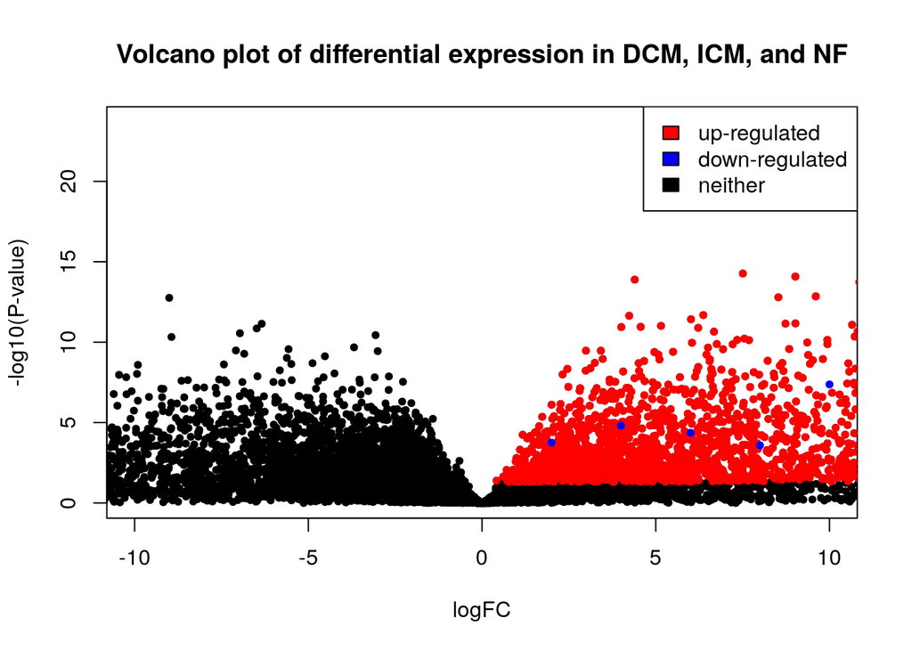

```r
plot(outputHits$logFC, -log10(outputHits$P.Value), pch = 20,
     main = "Volcano plot of differential expression in DCM, ICM, and NF",
     xlim = c(-10, 10),
     xlab = "logFC",
     ylab = "-log10(P-value)")

# color points based on if they're upregulated, down regulated or neither
# upregulated is red
upregulated <- outputHits[which(outputHits$P.Value < 0.05 & outputHits$logFC > 0), ]
with(upregulated, points(logFC, -log10(P.Value), pch = 20, col = "red"))

# make downregulated points blue
downregulated <- outputHits[which(outputHits$P.Value < 0.05 & outputHits$logFC < 0), ]
with(downregulated, points(logFC -log10(P.Value), pch = 20, col = "blue"))

legend("topright",
       legend = c("up-regulated", "down-regulated", "neither"),
       fill = c("red","blue", "black"),
       cex = 1)
```

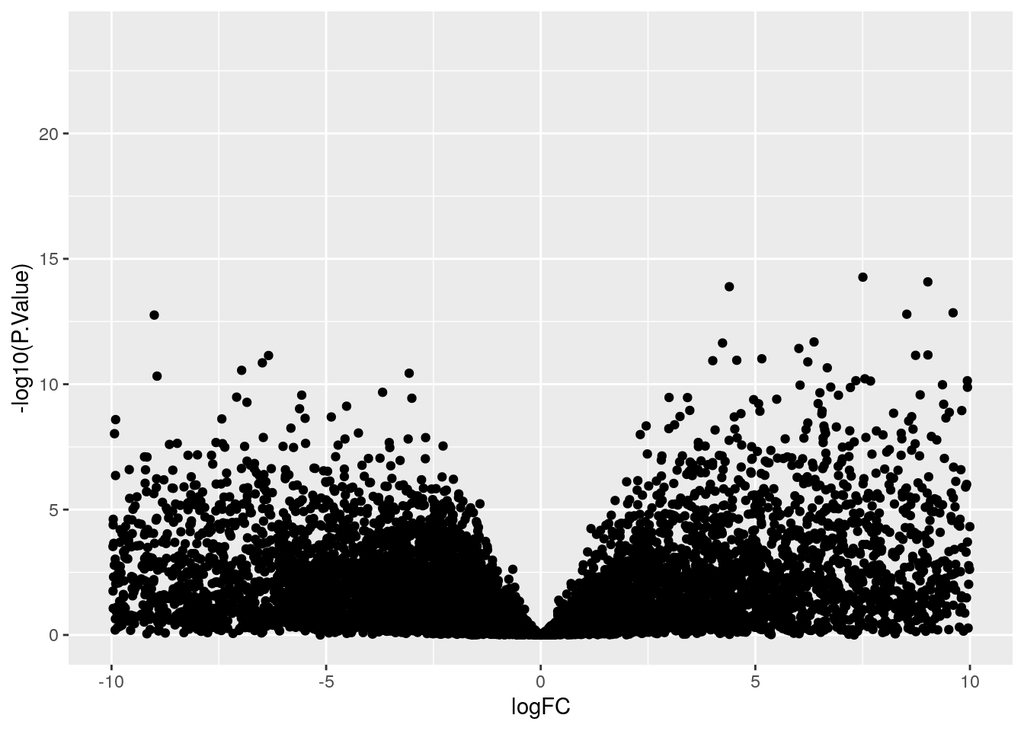

```r
# ggplot2::ggplot(outputHits, x=logFC, y=P.Value) +
#   ggplot2::geom_point(aes(x=logFC, y=P.Value)) +
#   ggplot2::xlim(-10, 10)
ggplot2::ggplot(outputHits, x=logFC, y=-log10(P.Value)) +
  ggplot2::geom_point(aes(x=logFC, y=-log10(P.Value))) +
  ggplot2::xlim(-10, 10)
```

Volcano plot for statistically significant differentially expressed genes past correction.

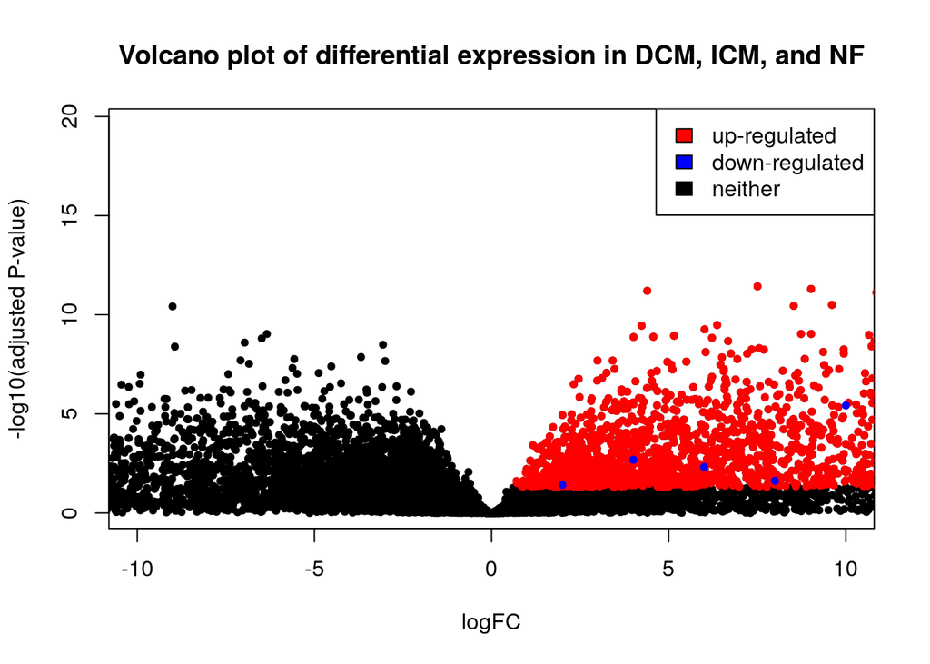

```r
plot(outputHits$logFC, -log10(outputHits$adj.P.Val), pch = 20,
     main = "Volcano plot of differential expression in DCM, ICM, and NF",
     xlim = c(-10, 10),
     xlab = "logFC",
     ylab = "-log10(adjusted P-value)")

# color points based on if they're upregulated, down regulated or neither
# upregulated is red
upregulated <- outputHits[which(outputHits$adj.P.Val < 0.05 & outputHits$logFC > 0), ]
with(upregulated, points(logFC, -log10(adj.P.Val), pch = 20, col = "red"))

# make downregulated points blue
downregulated <- outputHits[which(outputHits$adj.P.Val < 0.05 & outputHits$logFC < 0), ]
with(downregulated, points(logFC -log10(adj.P.Val), pch = 20, col = "blue"))

legend("topright",
       legend = c("up-regulated", "down-regulated", "neither"),
       fill = c("red","blue", "black"),
       cex = 1)
```

## Heatmap Let’s make a heatmap with the statistically significant genes both before and after correction.